# Pre-ACT Predictions Analysis

Victor Faner

## Context

Pre-ACT score reports include predicted ranges for how scholars will likely perform on the actual ACT, broken down by both Composite and individual subject scores. Here we measure the accuracy of these predictions longitudinally by examining historic performance on the unofficial Fall, Winter, and Official ACT exams administered throughout the network.

### Techincal Notes

- For scholars who took the Pre-ACT more than once, the prediction intervals were taken from the *most recent* administration.
- For scholars who took the official ACT more than once, their scores were taken from their *first* administration.
- These analyses *only* look at scholars who took all three administrations of the ACT (Unofficial Fall, Winter, and Official)

| local_id | predicted_score_low | predicted_score_high | test_type | scale_score | prediction_accuracy |
| --- | --- | --- | --- | --- | --- |
| 49954862426 | 21 | 24 | Unofficial Fall | 17 | Below Predicted Range |
| 49954836379 | 15 | 18 | Unofficial Fall | 12 | Below Predicted Range |
| 49954682540 | 18 | 21 | Official | 19 | Within Predicted Range |
| 50372329603 | 14 | 17 | Unofficial Fall | 11 | Below Predicted Range |
| 50371923755 | 16 | 19 | Unofficial Fall | 14 | Below Predicted Range |
| 50372230540 | 13 | 16 | Unofficial Fall | 12 | Below Predicted Range |
| 49954945515 | 18 | 21 | Unofficial Fall | 15 | Below Predicted Range |
| 50372607361 | 17 | 20 | Unofficial Fall | 20 | Within Predicted Range |
| 47868744744 | 20 | 23 | Official | 25 | Above Predicted Range |

## Accuracy Analysis

What percentage of scholars scored below, within, or above their predicted range for Official, Fall Unofficial, and Winter Unofficial?

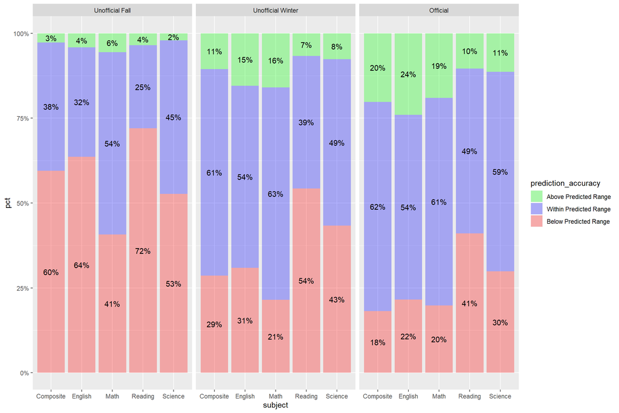

## Residuals Analysis

For the scholars who scored outside of their predicted range, how much better or worse did they do than the predicted upper or lower bounds, respectively?

The data suggest that, while scholars generally perform 1-3 points below expectation at first, over time the score differential narrows and trends upwards significantly. By the time scholars take the Official ACT, score performance is well aligned with 10th grade PreACT predictions.

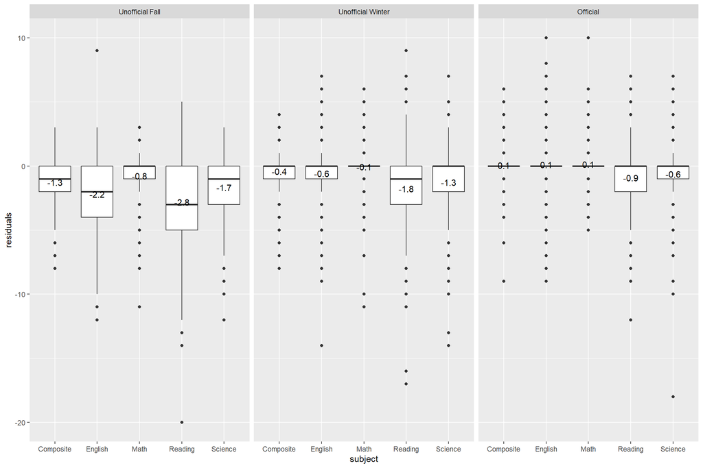

## Conclusions

In general, the accuracy of the Pre-ACT prediction intervals appears to improve over time. Among other factors, this may be due to practice effects: scholars taking the ACT/Pre-ACT multiple times may perform better simply due to repeated exposure to the same types of questions. Alternatively, since the PreACT and ACT are aligned with presumed 10th grade and 11th grade proficiency levels, scholars may not have the requisite skills to perform at expectation until they take the official ACT assessment at the end of 11th grade.

Overall, the data suggests that while the PreACT predictions may accurately reflect performance on the actual ACT, they may not be suitable goals for scholars while they are still gaining proficiency on unofficial benchmarks. For goal-setting purposes, expected performance on unofficial ACTs may need to be realigned to compensate for any interim deficiencies.